# NXS TCS Article — Topic Modelling Report

BERTopic clustering of the TCAC 2.0 corpus (UMAP + HDBSCAN)

Author

Rainer M. Krug

Published

July 8, 2026

[figure not shown]

Part of the Data Management Report

[figure not shown]

# Working Title

TCAC 2.0 — Transformative Change Assessment Corpus 2.0

## Code repo

[Github repository](https://github.com/IPBES-Data/TCAC-2.0)

# Introduction

This report documents the topic-modelling layer of TCAC 2.0. SPECTER2 embeddings of the corpus (produced and assessed in the Embedding Report) are reduced to a low-dimensional space with UMAP and clustered with HDBSCAN, using the [BERTopic](https://maartengr.github.io/BERTopic/) framework. Each work in the corpus and each keypaper is assigned a `topic_id`. Topics are summarised by per-topic c-TF-IDF vocabulary on the title + abstract text.

```r
library(targets)
library(arrow)
library(dplyr)
library(ggplot2)
library(htmltools)
library(knitr)
```

# Method

## Pipeline summary

The pipeline is orchestrated by `targets`. Stages relevant to this report:

1. **Embeddings** — SPECTER2 (768-d) on title, abstract and title+abstract variants. See the Embedding Report.
2. **UMAP** — reduce the primary variant (`title_abstract`) to `n_components = 5` dimensions for clustering, plus a 2-D projection for visualisation.
3. **HDBSCAN** — density-based clustering on the 5-D UMAP space.
4. **c-TF-IDF** — per-topic term scoring on the title+abstract text, producing the topic vocabulary.
5. **Fallback projection** — works without abstracts (and the keypapers without abstracts) are projected via the title variant onto the same UMAP+HDBSCAN fit and tagged `topic_source = "fallback"`.

## Parameters used

The BERTopic fit is identified by three things: the **embedding config** it consumes (which embedding model + which run produced the vectors), the **variant** of those embeddings used as the primary input, and the **BERTopic config** itself (UMAP + HDBSCAN + vectorizer knobs). All three are read from `input/config.yaml`.

```r
y <- yaml::read_yaml("input/config.yaml")
active_emb_cfg <- y$embeddings$active
active_btopic <- y$bertopic$active_runpod
cfg <- tar_read(bertopic_runpod_cfg)

# Show only the knobs that affect the fit (skip transport/ssh details).
knobs <- c(
  "method",
  "primary_variant",
  "fallback_variant",
  "center_embeddings",
  "umap_n_components",
  "umap_n_neighbors",
  "umap_min_dist",
  "umap_metric",
  "hdbscan_min_cluster_size",
  "hdbscan_min_samples",
  "top_n_words",
  "vectorizer_min_df",
  "vectorizer_max_df",
  "vectorizer_max_features",
  "vectorizer_ngram",
  "keypaper_threshold",
  "random_seed"
)
have <- intersect(knobs, names(cfg))

tibble::tibble(
  parameter = c("embedding config", "bertopic config", have),
  value = c(
    active_emb_cfg,
    active_btopic,
    vapply(
      have,
      function(k) {
        v <- cfg[[k]]
        if (is.null(v)) "—" else paste(v, collapse = ", ")
      },
      character(1)
    )
  )
) |>
  knitr::kable(
    caption = sprintf(
      "Active embedding config: %s · BERTopic config: %s · Primary variant: %s · Fallback variant: %s.",
      active_emb_cfg,
      active_btopic,
      cfg$primary_variant %||% "title_abstract",
      cfg$fallback_variant %||% "title"
    )
  )
```

Table 1: Active embedding config: SPECTER2_runpod · BERTopic config: runpod_v6_chapters · Primary variant: title_abstract · Fallback variant: title.

| parameter | value |
| --- | --- |
| embedding config | SPECTER2_runpod |
| bertopic config | runpod_v6_chapters |
| method | runpod |
| primary_variant | title_abstract |
| fallback_variant | title |
| umap_n_components | 5 |
| umap_n_neighbors | 15 |
| umap_min_dist | 0 |
| umap_metric | euclidean |
| hdbscan_min_cluster_size | 25 |
| hdbscan_min_samples | 5 |
| top_n_words | 15 |
| vectorizer_min_df | 2 |
| vectorizer_max_df | 0.95 |
| vectorizer_max_features | 20000 |
| vectorizer_ngram | 1, 2 |
| keypaper_threshold | 1 |
| random_seed | 13 |

# Results

## Topic count and corpus coverage

```r
# tar_read(topics_runpod) returns the path to topic_info.parquet
# inside the hive-partitioned leaf
# output/NXS_TCA_corpus/topics/config=<emb>/bertopic=<run>/variant=<v>/.
# Parse the three hive-partition keys out of the path so the report
# surfaces the active embedding config, bertopic config, and variant
# alongside the fit summary.
topic_info_path <- tar_read(topics_runpod)
topics_dir <- dirname(topic_info_path)
parts <- strsplit(topics_dir, "/", fixed = TRUE)[[1]]
leaf_emb_cfg <- sub("^config=", "", grep("^config=", parts, value = TRUE))
leaf_btopic <- sub("^bertopic=", "", grep("^bertopic=", parts, value = TRUE))
leaf_variant <- sub("^variant=", "", grep("^variant=", parts, value = TRUE))

ti <- arrow::read_parquet(topic_info_path)
tp <- arrow::open_dataset(file.path(topics_dir, "topics.parquet"))

n_works <- nrow(tp)
n_topics <- nrow(ti)
n_noise <- ti |>
  dplyr::filter(topic_id == -1L) |>
  dplyr::summarise(n = sum(n_corpus + n_keypapers)) |>
  dplyr::pull(n)
if (length(n_noise) == 0) {
  n_noise <- 0L
}
n_topics_real <- n_topics - as.integer(any(ti$topic_id == -1L))

tibble::tibble(
  metric = c(
    "Number of topics (incl. noise -1)",
    "Number of topics (excl. noise)",
    "Works assigned to a topic",
    "Works in noise cluster (-1)",
    "Noise share (%)"
  ),
  value = c(
    format(n_topics, big.mark = ","),
    format(n_topics_real, big.mark = ","),
    format(n_works - n_noise, big.mark = ","),
    format(n_noise, big.mark = ","),
    sprintf("%.2f", 100 * n_noise / n_works)
  )
) |>
  knitr::kable(
    align = c("l", "r"),
    caption = sprintf(
      "High-level summary of the BERTopic fit (embedding config: %s · bertopic config: %s · variant: %s).",
      leaf_emb_cfg,
      leaf_btopic,
      leaf_variant
    )
  )
```

Table 2: High-level summary of the BERTopic fit (embedding config: SPECTER2_runpod · bertopic config: runpod_v6_chapters · variant: title_abstract).

| metric | value |
| --- | --- |
| Number of topics (incl. noise -1) | 52 |
| Number of topics (excl. noise) | 51 |
| Works assigned to a topic | 3,164 |
| Works in noise cluster (-1) | 3,483 |
| Noise share (%) | 52.40 |

## Topic-size distribution

How is the corpus distributed across topics? A healthy fit shows many topics with roughly comparable sizes (heavy-tailed but not single-blob). A *collapsed* fit shows one topic absorbing the bulk of the corpus — easy to spot visually as one bar dwarfing the rest.

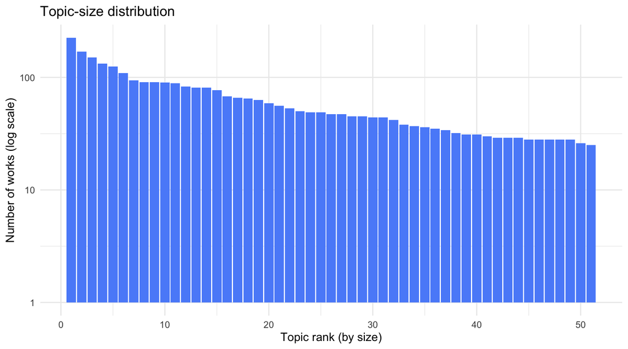

Figure 1

```r
# Placeholder: fig_topic_sizes is not yet wired as a tar_target — build
# inline from topic_info. Move to a target once the visualisation layer
# is finalised (see TODO_Visualisations.md §2).
ti |>
  dplyr::filter(topic_id >= 0L) |>
  dplyr::arrange(dplyr::desc(n_corpus)) |>
  dplyr::mutate(rank = dplyr::row_number()) |>
  ggplot2::ggplot(ggplot2::aes(x = rank, y = n_corpus)) +
  ggplot2::geom_col(fill = "#5B8FF9") +
  ggplot2::scale_y_log10(labels = scales::label_comma()) +
  ggplot2::labs(
    x = "Topic rank (by size)",
    y = "Number of works (log scale)",
    title = "Topic-size distribution"
  ) +
  ggplot2::theme_minimal(base_size = 12)
```

```r
ti |>
  dplyr::filter(topic_id >= 0L) |>
  dplyr::pull(n_corpus) |>
  quantile(probs = c(0, 0.05, 0.25, 0.5, 0.75, 0.95, 1)) |>
  tibble::enframe(name = "quantile", value = "topic size") |>
  dplyr::mutate(`topic size` = format(round(`topic size`), big.mark = ",")) |>
  knitr::kable(
    align = c("l", "r"),
    caption = "Quantiles of the topic-size distribution (noise excluded)."
  )
```

Table 3: Quantiles of the topic-size distribution (noise excluded).

| quantile | topic size |
| --- | --- |
| 0% | 25 |
| 5% | 28 |
| 25% | 32 |
| 50% | 47 |
| 75% | 81 |
| 95% | 142 |
| 100% | 225 |

## Topic vocabulary

For each topic: rank by size, top-N c-TF-IDF terms, count of works, count of keypapers in the topic, and the `is_relevant` flag (`n_keypapers ≥ keypaper_threshold`).

```r
tar_read(tbl_topics)
```

Table 4

| topic_id | is_relevant | n_keypapers | n_corpus | top_words | sample_titles |
| --- | --- | --- | --- | --- | --- |
| -1 | True | 60 | 3423 |  | The Liberal Limits of Environmental Law: A Green Legal Critique • Partitioned Nature, Privileged Knowledge: Community‐based Conservation in Tanzania • Health Impact Assessment in New South Wales &amp;… |
| 47 | True | 2 | 150 | indigenous, indigenous peoples, peoples, indigenous local, knowledge systems, local knowledge, et al, et, al, indigenous knowledge, health, communities, peoples local, ilk, food | Rediscovering the Potential of Indigenous Storytelling for Conservation Practice • Critical Investigations of Resilience: A Brief Introduction to Indigenous Environmental Studies &amp; Sciences • Clim… |
| 26 | False | 0 | 225 | sustainability, inner, transformative, transformation, learning, education, transformations, innovation, nature, behavior, action, governance, political, adaptation, values | Doing away with plastic shopping bags: international patterns of norm emergence and policy implementation • Digital social research, social media and the sociological imagination: surrogacy, augmentat… |
| 14 | False | 0 | 169 | nbs, urban, cities, nature, nature based, based solutions, flood, solutions, green, city, urban areas, biodiversity, planning, gi, infrastructure | Two decades of urban climate research: a review of turbulence, exchanges of energy and water, and the urban heat island • THE MILAN URBAN FOOD POLICY PACT: THE POTENTIAL OF FOOD AND THE KEY ROLE OF CI… |
| 28 | False | 0 | 133 | nexus, energy food, water energy, energy, food, wef, governance, food nexus, wef nexus, iwrm, food energy, energy water, nexus governance, resource, water nexus | Environmental policy integration: a state of the art review • Rescaling environmental governance, rethinking the state: A three-dimensional review • Regulatory Competition and Environmental Enforcemen… |
| 0 | False | 0 | 125 | disease, virus, zoonotic, infectious, health, pathogens, transmission, aedes, infection, diseases, dengue, borne, mosquito, outbreaks, species | Land-Use Change and Emerging Infectious Disease on an Island Continent • Rats, Cities, People, and Pathogens: A Systematic Review and Narrative Synthesis of Literature Regarding the Ecology of Rat-Ass… |
| 29 | False | 0 | 109 | la, en, que, el, del, los, las, se, para, les, en la, una, por, como, da | A New ′Conservation Space′? Protected Areas, Environmental Economic Activities and Discourses in Two Yucatán Biosphere Reserves in Mexico • Transiciones: a space for research and design for transition… |
| 37 | False | 0 | 94 | biodiversity, conservation, cbd, target, montreal, genetic resources, biodiversity framework, kunming, species, global biodiversity, gbf, convention, kunming montreal, genetic, cop 15 | Biodiversity for Billionaires: Capitalism, Conservation and the Role of Philanthropy in Saving/Selling Nature • Local costs of conservation exceed those borne by the global majority • Mainstreaming bi… |
| 9 | False | 0 | 91 | finance, financial, debt, biodiversity, monetary, nature, financing, banks, climate finance, swaps, bonds, sovereign, risks, private, capital | International financial subordination: a critical research agenda • Integrating biodiversity into financial decision‐making: Challenges and four principles • Paying for nature‐based solutions: A revie… |
| 34 | False | 0 | 91 | agroforestry, agriculture, agricultural, food, crop, intensification, agroecology, trees, soil, biodiversity, tree, production, agroecological, farming, sustainable intensification | Sustainable Intensification in Agriculture: Premises and Policies • The role of conservation agriculture in sustainable agriculture • Contribution of trees to the conservation of biodiversity and ecos… |

[output cut: 42 more lines]

## UMAP scatter

2-D UMAP of a sample of the corpus, with keypapers overlaid in full. Coordinates come from `viz_umap_coords` (sampled corpus, seed + `umap_sample_size` from `input/config.yaml: viz`).

```r
tar_read(viz_umap_fig)
```

[interactive chart not shown]

Figure 2

## UMAP with topic overlay

Same 2-D UMAP, points coloured by their `topic_id` from the 5-D HDBSCAN fit. Keypapers shown as larger markers in their own topic colour.

```r
tar_read(viz_topics_fig)
```

[interactive chart not shown]

Figure 3

# Keypaper coverage

Per keypaper: which topic does it land in, and does that topic clear the `keypaper_threshold` (`is_relevant = TRUE`)? Topics that capture ≥ `keypaper_threshold` keypapers are treated as on-corpus topics for downstream filtering.

```r
kp_topics <- arrow::open_dataset(file.path(topics_dir, "topics.parquet")) |>
  dplyr::filter(source == "keypaper") |>
  dplyr::select(id, topic_id, topic_source) |>
  dplyr::collect()

# Bring in keypaper titles directly from key_works.
kc <- arrow::open_dataset(tar_read(key_works)) |>
  dplyr::select(id, title) |>
  dplyr::collect() |>
  dplyr::mutate(citation = title)

kp_topics |>
  dplyr::left_join(kc, by = "id") |>
  dplyr::left_join(
    ti |> dplyr::select(topic_id, topic_name = label, is_relevant),
    by = "topic_id"
  ) |>
  dplyr::transmute(
    topic_id,
    topic = topic_name,
    relevant = ifelse(
      isTRUE(is_relevant) | is_relevant == TRUE,
      "<span style='color:green'>yes</span>",
      "<span style='color:red'>no</span>"
    ),
    source = topic_source,
    citation,
    title
  ) |>
  dplyr::arrange(topic_id) |>
  knitr::kable(
    format = "html",
    escape = FALSE,
    caption = "Topic assignment for each keypaper."
  )
```

Table 5: Topic assignment for each keypaper.

| topic_id | topic | relevant | source | citation | title |
| --- | --- | --- | --- | --- | --- |
| -1 | -1_noise | yes | projected | Karl Polanyi's “The Great Transformation” | Karl Polanyi's “The Great Transformation” |
| -1 | -1_noise | yes | projected | Social practice theory | Social practice theory |
| -1 | -1_noise | yes | projected | SHIFT | SHIFT |
| -1 | -1_noise | yes | projected | Fractal agency | Fractal agency |
| -1 | -1_noise | yes | projected | Everyday resistance | Everyday resistance |
| -1 | -1_noise | yes | projected | Transformative learning for social-ecological sustainability | Transformative learning for social-ecological sustainability |
| -1 | -1_noise | yes | projected | Ethnoecology | Ethnoecology |
| -1 | -1_noise | yes | projected | Human agency | Human agency |
| -1 | -1_noise | yes | projected | Epistemic communities | Epistemic communities |
| -1 | -1_noise | yes | projected | Phases of deliberate social-ecological transformations | Phases of deliberate social-ecological transformations |
| -1 | -1_noise | yes | projected | Structuration theory | Structuration theory |
| -1 | -1_noise | yes | projected | Three spheres of transformation | Three spheres of transformation |
| -1 | -1_noise | yes | projected | Sociotechnical infrastructures | Sociotechnical infrastructures |
| -1 | -1_noise | yes | projected | Environmental history: Environmentalism of the poors and environmental coloniality | Environmental history: Environmentalism of the poors and environmental coloniality |
| -1 | -1_noise | yes | projected | Transdisciplinary research | Transdisciplinary research |
| -1 | -1_noise | yes | projected | Transition governance | Transition governance |
| -1 | -1_noise | yes | projected | Rational choice theory | Rational choice theory |
| -1 | -1_noise | yes | projected | Institutional analysis | Institutional analysis |
| -1 | -1_noise | yes | projected | Governmentality | Governmentality |
| -1 | -1_noise | yes | projected | Pathways to nature connectedness | Pathways to nature connectedness |
| -1 | -1_noise | yes | projected | Participatory research | Participatory research |
| -1 | -1_noise | yes | projected | Redesigning theories of change | Redesigning theories of change |
| -1 | -1_noise | yes | projected | Ecological civilization | Ecological civilization |
| -1 | -1_noise | yes | projected | Decolonial feminisms and ecofeminisms | Decolonial feminisms and ecofeminisms |
| -1 | -1_noise | yes | projected | Regenerative approaches | Regenerative approaches |
| -1 | -1_noise | yes | projected | Panarchy theory | Panarchy theory |
| -1 | -1_noise | yes | projected | Collective action in social-ecological systems | Collective action in social-ecological systems |
| -1 | -1_noise | yes | projected | Transformation flower approach | Transformation flower approach |
| -1 | -1_noise | yes | projected | Value-centred leverage points to catalyze transformative change | Value-centred leverage points to catalyze transformative change |
| -1 | -1_noise | yes | projected | Actor network theory | Actor network theory |
| -1 | -1_noise | yes | projected | Inclusive innovation | Inclusive innovation |
| -1 | -1_noise | yes | projected | Degrowth and post-growth studies | Degrowth and post-growth studies |
| -1 | -1_noise | yes | projected | Political ecology | Political ecology |
| -1 | -1_noise | yes | projected | Catalysing transformation | Catalysing transformation |
| -1 | -1_noise | yes | projected | Sustainability transitions | Sustainability transitions |
| -1 | -1_noise | yes | projected | Marxist theory | Marxist theory |
| -1 | -1_noise | yes | projected | Behavioural economics | Behavioural economics |
| -1 | -1_noise | yes | projected | Transformative spaces | Transformative spaces |
| -1 | -1_noise | yes | projected | Social movement theory | Social movement theory |
| -1 | -1_noise | yes | projected | Leverage points for sustainability transformation | Leverage points for sustainability transformation |
| -1 | -1_noise | yes | projected | Transformative governance | Transformative governance |
| -1 | -1_noise | yes | projected | Praxis | Praxis |
| -1 | -1_noise | yes | projected | Transformative education | Transformative education |
| -1 | -1_noise | yes | projected | Transformative innovation policy | Transformative innovation policy |
| -1 | -1_noise | yes | projected | Technological and scientific constructivism | Technological and scientific constructivism |
| -1 | -1_noise | yes | projected | Seeds of good anthropocenes | Seeds of good anthropocenes |
| -1 | -1_noise | yes | projected | Metatheories of human action | Metatheories of human action |
| -1 | -1_noise | yes | projected | Strengthening accountability frameworks | Strengthening accountability frameworks |
| -1 | -1_noise | yes | projected | Biodiversity policy integration | Biodiversity policy integration |
| -1 | -1_noise | yes | projected | Feminist political ecology | Feminist political ecology |
| -1 | -1_noise | yes | projected | Agroecological transformations | Agroecological transformations |
| -1 | -1_noise | yes | projected | Transition management | Transition management |
| -1 | -1_noise | yes | projected | Environmental State and the green State | Environmental State and the green State |
| -1 | -1_noise | yes | projected | Three horizons | Three horizons |
| -1 | -1_noise | yes | projected | Transformative sustainability science | Transformative sustainability science |
| -1 | -1_noise | yes | projected | Integrative framework for transformative social change | Integrative framework for transformative social change |
| -1 | -1_noise | yes | projected | International political economy | International political economy |
| -1 | -1_noise | yes | projected | Inner transformation | Inner transformation |
| -1 | -1_noise | yes | projected | Relationality | Relationality |
| -1 | -1_noise | yes | projected | Regenerative dialogues for sustainable futures | Regenerative dialogues for sustainable futures |
| 47 | 47_indigenous_indigenous peoples_peoples_indigenous local | yes | projected | Local Biodiversity Outlook transitions | Local Biodiversity Outlook transitions |
| 47 | 47_indigenous_indigenous peoples_peoples_indigenous local | yes | projected | Relational values and relationality | Relational values and relationality |

```r
kp_topics |>
  dplyr::left_join(
    ti |> dplyr::select(topic_id, is_relevant, n_corpus),
    by = "topic_id"
  ) |>
  dplyr::summarise(
    keypapers = dplyr::n(),
    `works in same topics` = sum(n_corpus, na.rm = TRUE),
    .by = is_relevant
  ) |>
  dplyr::mutate(
    is_relevant = ifelse(is_relevant, "relevant topic", "off-corpus topic"),
    `works in same topics` = format(`works in same topics`, big.mark = ",")
  ) |>
  knitr::kable(
    align = c("l", "r", "r"),
    caption = "Keypaper distribution across relevant vs off-corpus topics."
  )
```

Table 6: Keypaper distribution across relevant vs off-corpus topics.

| is_relevant | keypapers | works in same topics |
| --- | --- | --- |
| relevant topic | 62 | 205,680 |

# Diagnostics

## Cluster collapse check

A single topic absorbing ≫ half the corpus is a strong indicator of either UMAP collapsing into one blob or HDBSCAN’s `min_cluster_size` being too large for the embedding density. The table below flags collapse if any topic holds ≥ 50% of the works.

```r
top_share <- ti |>
  dplyr::filter(topic_id >= 0L) |>
  dplyr::slice_max(n_corpus, n = 5) |>
  dplyr::mutate(
    share = n_corpus / sum(ti$n_corpus, na.rm = TRUE),
    share = sprintf("%.2f%%", 100 * share),
    n_corpus = format(n_corpus, big.mark = ",")
  ) |>
  dplyr::select(topic_id, label, n_corpus, share)
top_share |>
  knitr::kable(
    align = c("r", "l", "r", "r"),
    caption = "Top 5 topics by size — share of the corpus they absorb."
  )
```

Table 7: Top 5 topics by size — share of the corpus they absorb.

| topic_id | label | n_corpus | share |
| --- | --- | --- | --- |
| 26 | 26_sustainability_inner_transformative_transformation | 225 | 3.42% |
| 14 | 14_nbs_urban_cities_nature | 169 | 2.57% |
| 47 | 47_indigenous_indigenous peoples_peoples_indigenous local | 150 | 2.28% |
| 28 | 28_nexus_energy food_water energy_energy | 133 | 2.02% |
| 0 | 0_disease_virus_zoonotic_infectious | 125 | 1.90% |

## Primary vs fallback assignments

How many works are clustered via the primary (title+abstract) variant vs the title-only fallback?

```r
arrow::open_dataset(file.path(topics_dir, "topics.parquet")) |>
  dplyr::count(topic_source) |>
  dplyr::collect() |>
  dplyr::arrange(dplyr::desc(n)) |>
  dplyr::mutate(
    `%` = sprintf("%.2f", 100 * n / sum(n)),
    n = format(n, big.mark = ",")
  ) |>
  knitr::kable(
    align = c("l", "r", "r"),
    caption = "Assignment source per work (primary fit vs fallback projection)."
  )
```

Table 8: Assignment source per work (primary fit vs fallback projection).

| topic_source | n | % |
| --- | --- | --- |
| embedding | 4,720 | 71.01 |
| fallback | 1,865 | 28.06 |
| projected | 62 | 0.93 |

# Provenance

```r
tibble::tibble(
  item = c(
    "Topics leaf",
    "BERTopic config name",
    "Embedding config",
    "Primary variant",
    "Fallback variant"
  ),
  value = c(
    topics_dir,
    leaf_btopic,
    leaf_emb_cfg,
    leaf_variant,
    cfg$fallback_variant %||% "title"
  )
) |>
  knitr::kable(
    caption = "Pointers to the on-disk artefacts behind this report."
  )
```

Pointers to the on-disk artefacts behind this report.

| item | value |
| --- | --- |
| Topics leaf | output/NXS_TCA_corpus/topics/config=SPECTER2_runpod/bertopic=runpod_v6_chapters/variant=title_abstract |
| BERTopic config name | runpod_v6_chapters |
| Embedding config | SPECTER2_runpod |
| Primary variant | title_abstract |
| Fallback variant | title |